# Seattle Data Analysis

#### Number of Checkouts by Publisher for each Year

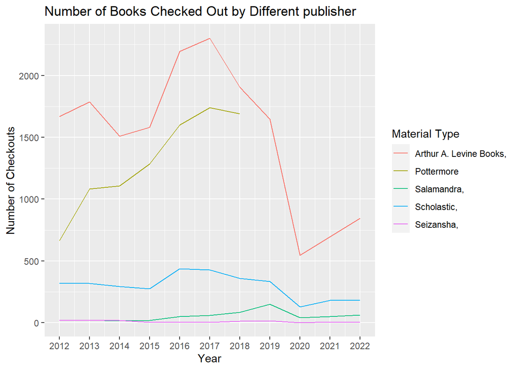

```r
#filtering data for publisher Arthur A.Levin Books, Pottermore, Scholastic, Salamandra and Seizansha.
data2 <- data%>%
  filter(Publisher %in% c("Arthur A. Levine Books,", "Pottermore",
                          "Scholastic,", "Salamandra,", "Seizansha,"))
# Aggregate data by MaterialType and Year
data_agg <- aggregate(Checkouts ~ Publisher + CheckoutYear, data2, sum)

# Create line graph
ggplot(data_agg, aes(x = CheckoutYear, y = Checkouts, color = Publisher)) +
  geom_line() +
  labs(title = "Number of Books Checked Out by Different publisher",
       x = "Year",
       y = "Number of Checkouts",
       color = "Material Type") +
  scale_x_continuous(breaks = seq(2012, 2022, 1))
```

#### Distribution of Checkout by Year

For this plot, I will use bar plot to visualize the distribution of number of checkouts for each year. The reason for this plot is to identify for which year the number of checkouts are highest and for which year the number of checkouts are lowest.

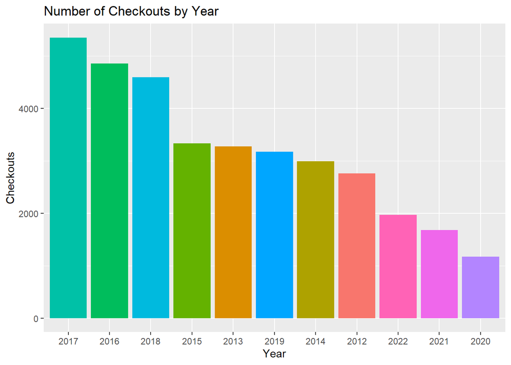

```r
#distribution of checkout by year
data$CheckoutYear <- as.factor(data$CheckoutYear)
data2 <- data[data$Checkouts < 300,]
data2%>%
  group_by(CheckoutYear)%>%
  summarise(Checkouts = sum(Checkouts))%>%
  ggplot(aes(x = reorder(CheckoutYear, -Checkouts), y = Checkouts, fill = CheckoutYear)) +
  geom_bar(stat = "identity") +
  labs(title = "Number of Checkouts by Year", x = "Year") +
  theme(legend.position = "none")
```

From the above plot, it can be seen that year 2017 has highest number of checkouts followed 2016 and 2018. The plot also shows that the year 2020 has lowest number of checkouts followed by 2021 and 2022. The year 2015, 2013, 2019, and 2014 has minor difference in the number of checkouts.